# Dự đoán Khả năng Vỡ nợ Thẻ Tín dụng

Nhóm 10 | Lâm Ngọc Yến Vy — 24133076 | Trần Thị Quế Trân — 24133067 | Tô Thuỷ Tiên — 24133062 | Phạm Thị Thảo Ngân — 24133041

2026-06-25

# 1 Tóm tắt

# 2 Giới thiệu

## 2.1 Bối cảnh

Thẻ tín dụng là một trong những sản phẩm tài chính phổ biến nhất hiện nay. Khi khách hàng không thanh toán được nợ đến hạn — tức là **vỡ nợ** (default) — ngân hàng phải chịu tổn thất tài chính trực tiếp. Theo thống kê ngành, tỷ lệ vỡ nợ thẻ tín dụng trung bình dao động từ 1–5% ở các thị trường phát triển, nhưng có thể cao hơn nhiều ở thị trường mới nổi.

Nếu ngân hàng có thể **dự đoán sớm** khách hàng nào có khả năng vỡ nợ trong tháng tới, họ có thể chủ động can thiệp: nhắc nhở thanh toán, điều chỉnh hạn mức, hoặc áp dụng chính sách tín dụng phù hợp — giảm thiểu rủi ro trước khi vỡ nợ xảy ra.

## 2.2 Mục tiêu và câu hỏi nghiên cứu

Dự án đặt ra ba câu hỏi nghiên cứu cụ thể:

1. **Yếu tố rủi ro nào liên quan mạnh nhất đến khả năng vỡ nợ?** → Trả lời qua EDA (Mục 4) và hệ số Odds Ratio của Hồi quy Logistic (Mục 6.1).
2. **Trong ba mô hình phân loại, mô hình nào dự đoán tốt nhất?** → Trả lời qua bảng so sánh AUC, Sensitivity, F1 (Mục 6.4).
3. **Biến nào có sức ảnh hưởng lớn nhất theo đánh giá của mô hình?** → Trả lời qua Feature Importance của Random Forest (Mục 6.3).

## 2.3 Phương pháp tiếp cận

Quy trình phân tích gồm 5 bước: **(1)** Tiền xử lý và làm sạch dữ liệu → **(2)** Phân tích dữ liệu khám phá (EDA) → **(3)** Xây dựng ba mô hình phân loại → **(4)** So sánh hiệu suất → **(5)** Rút ra kết luận và đề xuất.

# 3 Dữ liệu

## 3.1 Nguồn dữ liệu

Bộ dữ liệu **“Default of Credit Card Clients”** được lấy từ [UCI Machine Learning Repository](https://archive.ics.uci.edu/dataset/350/default+of+credit+card+clients), do I-Cheng Yeh công bố năm 2009. Đây là dữ liệu thực tế ghi nhận thông tin tín dụng của 30.000 khách hàng tại Đài Loan trong giai đoạn tháng 4–9/2005.

## 3.2 Mô tả biến

### 3.2.1 Đọc và kiểm tra dữ liệu

```r
credit_raw <- read.csv("data/UCI_Credit_Card.csv")
cat("Số dòng:", nrow(credit_raw), "| Số cột:", ncol(credit_raw), "\n")
```

```
## Số dòng: 30000 | Số cột: 25
```

```r
cat("Tổng số giá trị NA:", sum(is.na(credit_raw)), "\n")
```

```
## Tổng số giá trị NA: 0
```

```r
colSums(is.na(credit_raw))
```

```
##                         ID                  LIMIT_BAL
##                          0                          0
##                        SEX                  EDUCATION
##                          0                          0
##                   MARRIAGE                        AGE
##                          0                          0
##                      PAY_0                      PAY_2
##                          0                          0
##                      PAY_3                      PAY_4
##                          0                          0
##                      PAY_5                      PAY_6
##                          0                          0
##                  BILL_AMT1                  BILL_AMT2
##                          0                          0
##                  BILL_AMT3                  BILL_AMT4
##                          0                          0
##                  BILL_AMT5                  BILL_AMT6
##                          0                          0
##                   PAY_AMT1                   PAY_AMT2
##                          0                          0
##                   PAY_AMT3                   PAY_AMT4
##                          0                          0
##                   PAY_AMT5                   PAY_AMT6
##                          0                          0
## default.payment.next.month
##                          0
```

```r
cat("Số dòng trùng lặp:", sum(duplicated(credit_raw)), "\n")
```

```
## Số dòng trùng lặp: 0
```

```r
credit_clean <- credit_raw[!duplicated(credit_raw), ]
```

**Nhận xét:** Bộ dữ liệu không có giá trị thiếu (NA = 0) và không có dòng trùng lặp — đây là điểm thuận lợi so với nhiều bộ dữ liệu thực tế. Tuy nhiên vẫn tồn tại **giá trị mã hóa bất thường** trong biến phân loại cần xử lý ở bước tiếp theo.

### 3.2.2 Xử lý giá trị bất thường trong biến phân loại

Khi kiểm tra bảng mã (codebook) gốc của tác giả:

- Biến **EDUCATION** chỉ định nghĩa 4 giá trị hợp lệ (1=Sau đại học, 2=Đại học, 3=Trung học, 4=Khác), nhưng thực tế còn xuất hiện giá trị 0, 5, 6 — tổng cộng **345 quan sát** không có nghĩa theo mã gốc.
- Biến **MARRIAGE** chỉ định nghĩa 3 giá trị (1=Đã kết hôn, 2=Độc thân, 3=Khác), nhưng xuất hiện giá trị 0 với **54 quan sát**.

Quyết định xử lý: gộp các giá trị bất thường vào nhóm “Khác” thay vì xóa bỏ, vì số lượng nhỏ (< 2%) và xóa có thể làm mất thông tin.

```r
for (var in c("SEX", "EDUCATION", "MARRIAGE")) {
  cat(var)
  print(table(credit_raw[[var]]))
  cat("\n")
}
```

```
## SEX
##     1     2
## 11888 18112
##
## EDUCATION
##     0     1     2     3     4     5     6
##    14 10585 14030  4917   123   280    51
##
## MARRIAGE
##     0     1     2     3
##    54 13659 15964   323
```

```r
credit_clean$EDUCATION[credit_clean$EDUCATION %in% c(0, 5, 6)] <- 4
credit_clean$MARRIAGE[credit_clean$MARRIAGE == 0] <- 3

credit_clean$SEX <- factor(credit_clean$SEX,
  levels = c(1, 2), labels = c("Male", "Female"))

credit_clean$EDUCATION <- factor(credit_clean$EDUCATION,
  levels = c(1, 2, 3, 4),
  labels = c("Graduate School", "University", "High School", "Others"))

credit_clean$MARRIAGE <- factor(credit_clean$MARRIAGE,
  levels = c(1, 2, 3), labels = c("Married", "Single", "Others"))

credit_clean$default.payment.next.month <- factor(
  credit_clean$default.payment.next.month,
  levels = c(0, 1), labels = c("No Default", "Default"))

str(credit_clean)
```

```
## 'data.frame':    30000 obs. of  25 variables:
##  $ ID                        : int  1 2 3 4 5 6 7 8 9 10 ...
##  $ LIMIT_BAL                 : num  20000 120000 90000 50000 50000 50000 500000 100000 140000 20000 ...
##  $ SEX                       : Factor w/ 2 levels "Male","Female": 2 2 2 2 1 1 1 2 2 1 ...
##  $ EDUCATION                 : Factor w/ 4 levels "Graduate School",..: 2 2 2 2 2 1 1 2 3 3 ...
##  $ MARRIAGE                  : Factor w/ 3 levels "Married","Single",..: 1 2 2 1 1 2 2 2 1 2 ...
##  $ AGE                       : int  24 26 34 37 57 37 29 23 28 35 ...
##  $ PAY_0                     : int  2 -1 0 0 -1 0 0 0 0 -2 ...
##  $ PAY_2                     : int  2 2 0 0 0 0 0 -1 0 -2 ...
##  $ PAY_3                     : int  -1 0 0 0 -1 0 0 -1 2 -2 ...
##  $ PAY_4                     : int  -1 0 0 0 0 0 0 0 0 -2 ...
##  $ PAY_5                     : int  -2 0 0 0 0 0 0 0 0 -1 ...
##  $ PAY_6                     : int  -2 2 0 0 0 0 0 -1 0 -1 ...
##  $ BILL_AMT1                 : num  3913 2682 29239 46990 8617 ...
##  $ BILL_AMT2                 : num  3102 1725 14027 48233 5670 ...
##  $ BILL_AMT3                 : num  689 2682 13559 49291 35835 ...
##  $ BILL_AMT4                 : num  0 3272 14331 28314 20940 ...
##  $ BILL_AMT5                 : num  0 3455 14948 28959 19146 ...
##  $ BILL_AMT6                 : num  0 3261 15549 29547 19131 ...
##  $ PAY_AMT1                  : num  0 0 1518 2000 2000 ...
##  $ PAY_AMT2                  : num  689 1000 1500 2019 36681 ...
##  $ PAY_AMT3                  : num  0 1000 1000 1200 10000 657 38000 0 432 0 ...
##  $ PAY_AMT4                  : num  0 1000 1000 1100 9000 ...
##  $ PAY_AMT5                  : num  0 0 1000 1069 689 ...
##  $ PAY_AMT6                  : num  0 2000 5000 1000 679 ...
##  $ default.payment.next.month: Factor w/ 2 levels "No Default","Default": 2 2 1 1 1 1 1 1 1 1 ...
```

```r
summary(credit_clean)
```

```
##        ID          LIMIT_BAL           SEX                  EDUCATION
##  Min.   :    1   Min.   :  10000   Male  :11888   Graduate School:10585
##  1st Qu.: 7501   1st Qu.:  50000   Female:18112   University     :14030
##  Median :15000   Median : 140000                  High School    : 4917
##  Mean   :15000   Mean   : 167484                  Others         :  468
##  3rd Qu.:22500   3rd Qu.: 240000
##  Max.   :30000   Max.   :1000000
##     MARRIAGE          AGE            PAY_0             PAY_2
##  Married:13659   Min.   :21.00   Min.   :-2.0000   Min.   :-2.0000
##  Single :15964   1st Qu.:28.00   1st Qu.:-1.0000   1st Qu.:-1.0000
##  Others :  377   Median :34.00   Median : 0.0000   Median : 0.0000
##                  Mean   :35.49   Mean   :-0.0167   Mean   :-0.1338
##                  3rd Qu.:41.00   3rd Qu.: 0.0000   3rd Qu.: 0.0000
##                  Max.   :79.00   Max.   : 8.0000   Max.   : 8.0000
##      PAY_3             PAY_4             PAY_5             PAY_6
##  Min.   :-2.0000   Min.   :-2.0000   Min.   :-2.0000   Min.   :-2.0000
##  1st Qu.:-1.0000   1st Qu.:-1.0000   1st Qu.:-1.0000   1st Qu.:-1.0000
##  Median : 0.0000   Median : 0.0000   Median : 0.0000   Median : 0.0000
##  Mean   :-0.1662   Mean   :-0.2207   Mean   :-0.2662   Mean   :-0.2911
##  3rd Qu.: 0.0000   3rd Qu.: 0.0000   3rd Qu.: 0.0000   3rd Qu.: 0.0000
##  Max.   : 8.0000   Max.   : 8.0000   Max.   : 8.0000   Max.   : 8.0000
##    BILL_AMT1         BILL_AMT2        BILL_AMT3         BILL_AMT4
##  Min.   :-165580   Min.   :-69777   Min.   :-157264   Min.   :-170000
##  1st Qu.:   3559   1st Qu.:  2985   1st Qu.:   2666   1st Qu.:   2327
##  Median :  22382   Median : 21200   Median :  20088   Median :  19052
##  Mean   :  51223   Mean   : 49179   Mean   :  47013   Mean   :  43263
##  3rd Qu.:  67091   3rd Qu.: 64006   3rd Qu.:  60165   3rd Qu.:  54506
##  Max.   : 964511   Max.   :983931   Max.   :1664089   Max.   : 891586
##    BILL_AMT5        BILL_AMT6          PAY_AMT1         PAY_AMT2
##  Min.   :-81334   Min.   :-339603   Min.   :     0   Min.   :      0
##  1st Qu.:  1763   1st Qu.:   1256   1st Qu.:  1000   1st Qu.:    833
##  Median : 18104   Median :  17071   Median :  2100   Median :   2009
##  Mean   : 40311   Mean   :  38872   Mean   :  5664   Mean   :   5921
##  3rd Qu.: 50190   3rd Qu.:  49198   3rd Qu.:  5006   3rd Qu.:   5000
##  Max.   :927171   Max.   : 961664   Max.   :873552   Max.   :1684259
##     PAY_AMT3         PAY_AMT4         PAY_AMT5           PAY_AMT6
##  Min.   :     0   Min.   :     0   Min.   :     0.0   Min.   :     0.0
##  1st Qu.:   390   1st Qu.:   296   1st Qu.:   252.5   1st Qu.:   117.8
##  Median :  1800   Median :  1500   Median :  1500.0   Median :  1500.0
##  Mean   :  5226   Mean   :  4826   Mean   :  4799.4   Mean   :  5215.5
##  3rd Qu.:  4505   3rd Qu.:  4013   3rd Qu.:  4031.5   3rd Qu.:  4000.0
##  Max.   :896040   Max.   :621000   Max.   :426529.0   Max.   :528666.0
##  default.payment.next.month
##  No Default:23364
##  Default   : 6636
##
##
##
##
```

### 3.2.3 Kỹ thuật đặc trưng (Feature Engineering)

Phân tích tương quan (Mục 4.5) cho thấy sáu cột `BILL_AMT1`–`BILL_AMT6` tương quan lẫn nhau rất cao (r = 0,80–0,95). Đây gọi là **đa cộng tuyến** (multicollinearity): khi hai biến độc lập tương quan quá cao, mô hình Hồi quy Logistic không thể phân biệt được ảnh hưởng riêng của từng biến, dẫn đến hệ số ước lượng không ổn định.

```r
# Dùng list để nhóm biến theo chức năng
credit_list <- list(
  Customer = credit_clean[, c("ID", "LIMIT_BAL", "SEX", "AGE")],
  Bill     = credit_clean[, grep("BILL_AMT", names(credit_clean))],
  Payment  = credit_clean[, grep("PAY_AMT",  names(credit_clean))]
)
cat("Các nhóm trong credit_list:", names(credit_list), "\n")
```

```
## Các nhóm trong credit_list: Customer Bill Payment
```

```r
# Dùng matrix để tính tổng dư nợ
bill_matrix <- as.matrix(credit_clean[,grep("BILL_AMT", names(credit_clean))])
credit_clean$total_bill <- rowSums(bill_matrix)

high_debt <- subset(credit_clean, total_bill > 500000)
cat("Số khách hàng có tổng dư nợ > 500.000 NT$:", nrow(high_debt), "\n")
```

```
## Số khách hàng có tổng dư nợ > 500.000 NT$: 5114
```

```r
credit_final <- credit_clean %>%
  select(-ID) %>%
  rename(DEFAULT = default.payment.next.month) %>%
  mutate(
    # MAX_DELAY: số tháng trễ hạn lớn nhất trong 6 tháng gần nhất
    # Lý do: một lần trễ nặng (3 tháng) nguy hiểm hơn nhiều so với
    # trễ nhẹ đều đặn mỗi tháng — correlation với target r = 0,33
    MAX_DELAY   = pmax(PAY_0, PAY_2, PAY_3, PAY_4, PAY_5, PAY_6),

    # UTIL_RATE: tỷ lệ sử dụng hạn mức = dư nợ trung bình / hạn mức
    # Lý do: dư nợ 500k với hạn mức 1 triệu (50%) khác hẳn dư nợ 500k
    # với hạn mức 600k (83%) — tỷ lệ mới phản ánh đúng mức độ căng thẳng tài chính
    AVG_BILL    = rowMeans(select(., BILL_AMT1:BILL_AMT6)),
    UTIL_RATE   = pmax(pmin(AVG_BILL / LIMIT_BAL, 3), 0),

    # AVG_PAY_AMT: thanh toán trung bình 6 tháng — thay thế 6 cột riêng lẻ
    AVG_PAY_AMT = rowMeans(select(., PAY_AMT1:PAY_AMT6)),

    # REPAY_RATIO: tỷ lệ hoàn trả = số tiền trả / dư nợ
    # Phân biệt khách hàng trả đủ 100% vs chỉ trả tối thiểu
    REPAY_RATIO = pmax(pmin(ifelse(AVG_BILL > 0, AVG_PAY_AMT / AVG_BILL, 1), 2), 0),

    # Đổi nhãn target sang tiếng Việt để nhất quán với toàn bộ báo cáo
    DEFAULT     = factor(DEFAULT,
                         levels = c("No Default", "Default"),
                         labels = c("Không", "Có"))
  )

cat("credit_final:", nrow(credit_final), "dòng |",
    ncol(credit_final), "cột\n")
```

```
## credit_final: 30000 dòng | 30 cột
```

```r
cat("Biến mục tiêu (DEFAULT):", levels(credit_final$DEFAULT), "\n")
```

```
## Biến mục tiêu (DEFAULT): Không Có
```

## 3.3 Dữ liệu cuối cùng

```r
glimpse(credit_final)
```

```
## Rows: 30,000
## Columns: 30
## $ LIMIT_BAL   <dbl> 20000, 120000, 90000, 50000, 50000, 50000, 500000, 100000,…
## $ SEX         <fct> Female, Female, Female, Female, Male, Male, Male, Female, …
## $ EDUCATION   <fct> University, University, University, University, University…
## $ MARRIAGE    <fct> Married, Single, Single, Married, Married, Single, Single,…
## $ AGE         <int> 24, 26, 34, 37, 57, 37, 29, 23, 28, 35, 34, 51, 41, 30, 29…
## $ PAY_0       <int> 2, -1, 0, 0, -1, 0, 0, 0, 0, -2, 0, -1, -1, 1, 0, 1, 0, 0,…
## $ PAY_2       <int> 2, 2, 0, 0, 0, 0, 0, -1, 0, -2, 0, -1, 0, 2, 0, 2, 0, 0, -…
## $ PAY_3       <int> -1, 0, 0, 0, -1, 0, 0, -1, 2, -2, 2, -1, -1, 2, 0, 0, 2, 0…
## $ PAY_4       <int> -1, 0, 0, 0, 0, 0, 0, 0, 0, -2, 0, -1, -1, 0, 0, 0, 2, -1,…
## $ PAY_5       <int> -2, 0, 0, 0, 0, 0, 0, 0, 0, -1, 0, -1, -1, 0, 0, 0, 2, -1,…
## $ PAY_6       <int> -2, 2, 0, 0, 0, 0, 0, -1, 0, -1, -1, 2, -1, 2, 0, 0, 2, -1…
## $ BILL_AMT1   <dbl> 3913, 2682, 29239, 46990, 8617, 64400, 367965, 11876, 1128…
## $ BILL_AMT2   <dbl> 3102, 1725, 14027, 48233, 5670, 57069, 412023, 380, 14096,…
```

[output cut: 17 more lines]

# 4 Trực quan hóa dữ liệu (EDA)

Phần này khám phá dữ liệu sau xử lý nhằm hai mục tiêu: **(1)** hiểu cơ cấu khách hàng trong mẫu, và **(2)** xác định những biến có khả năng liên quan đến vỡ nợ — làm cơ sở lựa chọn và giải thích mô hình ở Mục 5.

## 4.1 Phân phối biến mục tiêu

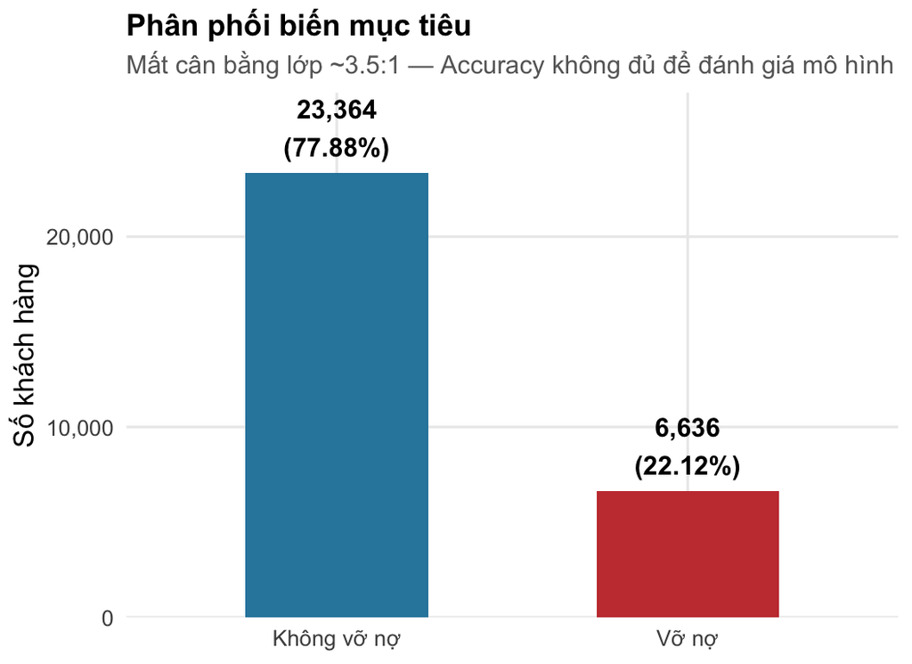

Hình 4.1. Phân phối biến mục tiêu (DEFAULT)

```r
target_summary <- credit_eda %>%
  count(DEFAULT) %>%
  mutate(pct = n / sum(n))

ggplot(target_summary, aes(x = DEFAULT, y = n, fill = DEFAULT)) +
  geom_col(width = 0.52, show.legend = FALSE) +
  geom_text(aes(label = paste0(comma(n), "\n(", percent(pct, accuracy = 0.01), ")")),
            vjust = -0.3, size = 4, fontface = "bold") +
  scale_fill_manual(values = palette_default) +
  scale_y_continuous(expand = expansion(mult = c(0, 0.18)),
                     labels = comma_format()) +
  labs(title    = "Phân phối biến mục tiêu",
       subtitle = "Mất cân bằng lớp ~3.5:1 — Accuracy không đủ để đánh giá mô hình",
       x = NULL, y = "Số khách hàng") +
  theme_b(12)
```

**Nhận xét:** Trong 30.000 khách hàng, có **23.364 người không vỡ nợ (77,88%)** và **6.636 người vỡ nợ (22,12%)** — tỷ lệ mất cân bằng khoảng 3,5:1.

Đây là vấn đề quan trọng cần chú ý: nếu một mô hình **luôn dự đoán “không vỡ nợ”** cho tất cả khách hàng, nó vẫn đạt Accuracy ≈ 78% — trông có vẻ tốt, nhưng thực chất vô dụng vì không phát hiện được ai vỡ nợ thật sự (Recall = 0%). Vì vậy, nhóm sử dụng **AUC-ROC, Sensitivity (Recall) và F1-Score** làm chỉ số đánh giá chính ở Mục 6, thay vì chỉ dựa vào Accuracy.

## 4.2 Phân tích đơn biến — Đặc điểm nhân khẩu học

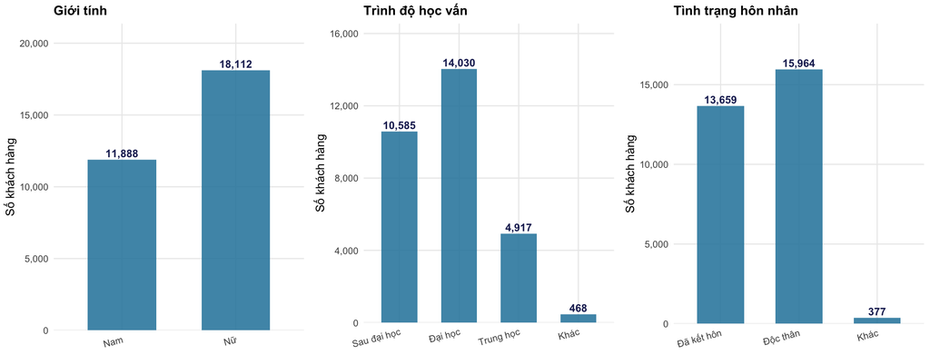

Hình 4.2. Cơ cấu khách hàng theo giới tính, học vấn và hôn nhân

```r
plot_count <- function(data, var, var_label) {
  df_tmp <- data %>% count(.data[[var]])
  ggplot(df_tmp, aes(x = .data[[var]], y = n)) +
    geom_col(fill = "#2E86AB", alpha = 0.88, width = 0.6) +
    geom_text(aes(label = comma(n)), vjust = -0.35, size = 3.2,
              fontface = "bold", color = "#1E2761") +
    scale_y_continuous(expand = expansion(mult = c(0, 0.18)),
                       labels = comma_format()) +
    labs(title = var_label, x = NULL, y = "Số khách hàng") +
    theme_b(10) +
    theme(axis.text.x = element_text(angle = 15, hjust = 1))
}

grid.arrange(
  plot_count(credit_eda, "SEX_label",       "Giới tính"),
  plot_count(credit_eda, "EDUCATION_label", "Trình độ học vấn"),
  plot_count(credit_eda, "MARRIAGE_label",  "Tình trạng hôn nhân"),
  ncol = 3
)
```

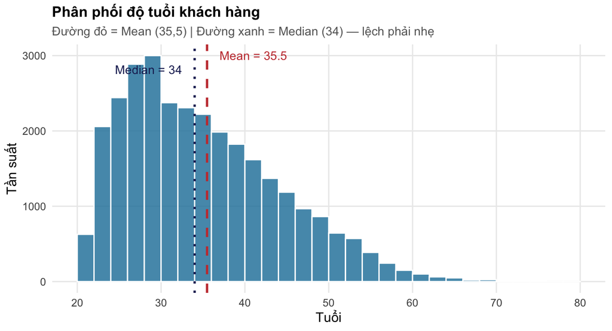

Hình 4.3. Phân phối độ tuổi khách hàng

```r
age_mean   <- mean(credit_eda$AGE)
age_median <- median(credit_eda$AGE)

ggplot(credit_eda, aes(x = AGE)) +
  geom_histogram(bins = 30, fill = "#2E86AB", color = "white", alpha = 0.85) +
  geom_vline(xintercept = age_mean,   linetype = "dashed",
             color = "#C73E3E", linewidth = 0.9) +
  geom_vline(xintercept = age_median, linetype = "dotted",
             color = "#1E2761", linewidth = 0.9) +
  annotate("text", x = age_mean + 1.5, y = Inf, vjust = 1.8,
           label = paste0("Mean = ", round(age_mean, 1)),
           color = "#C73E3E", size = 3.5, hjust = 0) +
  annotate("text", x = age_median - 1.5, y = Inf, vjust = 3.4,
           label = paste0("Median = ", age_median),
           color = "#1E2761", size = 3.5, hjust = 1) +
  scale_x_continuous(breaks = seq(20, 80, 10)) +
  labs(title    = "Phân phối độ tuổi khách hàng",
       subtitle = "Đường đỏ = Mean (35,5) | Đường xanh = Median (34) — lệch phải nhẹ",
       x = "Tuổi", y = "Tần suất") +
  theme_b(11)
```

**Nhận xét:**

- **Giới tính:** Nữ chiếm đa số (18.112 người — 60,4%). Điều này phản ánh đặc điểm thực tế của thị trường thẻ tín dụng tại Đài Loan giai đoạn 2005.
- **Học vấn:** Tập trung chủ yếu ở Đại học (14.030 người) và Sau đại học (10.585 người). Dữ liệu phản ánh nhóm khách hàng có học vấn tương đối cao — phù hợp với đặc điểm người dùng thẻ tín dụng.
- **Hôn nhân:** Đã kết hôn (13.659) và Độc thân (15.964) chiếm phần lớn.
- **Tuổi:** Phân phối lệch phải nhẹ — Mean (35,5) lớn hơn Median (34) do một số khách hàng lớn tuổi kéo đuôi phải. Độ tuổi làm việc (25–45) chiếm đa số.

## 4.3 Phân tích đơn biến — Đặc điểm tài chính

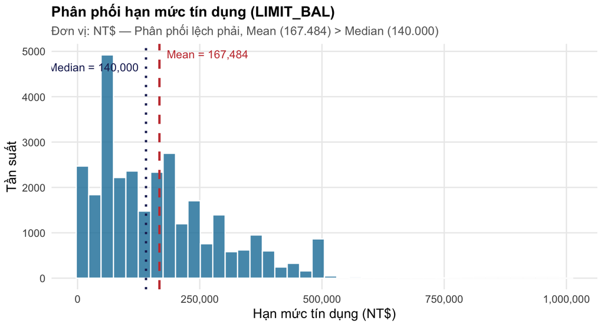

Hình 4.4. Phân phối hạn mức tín dụng (LIMIT_BAL)

```r
lim_mean   <- mean(credit_eda$LIMIT_BAL)
lim_median <- median(credit_eda$LIMIT_BAL)

ggplot(credit_eda, aes(x = LIMIT_BAL)) +
  geom_histogram(bins = 40, fill = "#2E86AB", color = "white", alpha = 0.85) +
  geom_vline(xintercept = lim_mean,   linetype = "dashed",
             color = "#C73E3E", linewidth = 0.9) +
  geom_vline(xintercept = lim_median, linetype = "dotted",
             color = "#1E2761", linewidth = 0.9) +
  annotate("text", x = lim_mean + 15000, y = Inf, vjust = 1.8,
           label = paste0("Mean = ", comma(round(lim_mean))),
           color = "#C73E3E", size = 3.3, hjust = 0) +
  annotate("text", x = lim_median - 15000, y = Inf, vjust = 3.4,
           label = paste0("Median = ", comma(lim_median)),
           color = "#1E2761", size = 3.3, hjust = 1) +
  scale_x_continuous(labels = comma_format()) +
  labs(title    = "Phân phối hạn mức tín dụng (LIMIT_BAL)",
       subtitle = "Đơn vị: NT$ — Phân phối lệch phải, Mean (167.484) > Median (140.000)",
       x = "Hạn mức tín dụng (NT$)", y = "Tần suất") +
  theme_b(11)
```

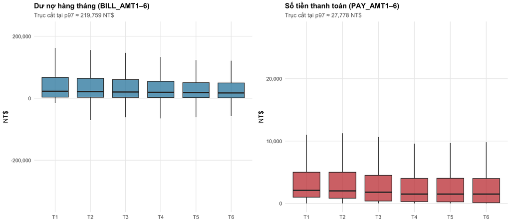

Hình 4.5. Phân phối dư nợ và thanh toán theo từng tháng (trục cắt tại phân vị 97% để dễ đọc)

```r
bill_cap <- quantile(unlist(select(credit_eda, starts_with("BILL_AMT"))),
                     0.97, na.rm = TRUE)
pay_cap  <- quantile(unlist(select(credit_eda, starts_with("PAY_AMT"))),
                     0.97, na.rm = TRUE)

bill_long <- credit_eda %>%
  select(starts_with("BILL_AMT")) %>%
  pivot_longer(everything(), names_to = "Thang", values_to = "gia_tri") %>%
  mutate(Thang = factor(Thang, levels = paste0("BILL_AMT", 1:6),
                        labels = paste0("T", 1:6)))

pay_long <- credit_eda %>%
  select(starts_with("PAY_AMT")) %>%
  pivot_longer(everything(), names_to = "Thang", values_to = "gia_tri") %>%
  mutate(Thang = factor(Thang, levels = paste0("PAY_AMT", 1:6),
                        labels = paste0("T", 1:6)))

p_bill <- ggplot(bill_long, aes(x = Thang, y = gia_tri)) +
  geom_boxplot(fill = "#2E86AB", alpha = 0.75, outlier.shape = NA) +
  coord_cartesian(ylim = c(NA, bill_cap)) +
  scale_y_continuous(labels = comma_format()) +
  labs(title    = "Dư nợ hàng tháng (BILL_AMT1–6)",
       subtitle = paste0("Trục cắt tại p97 ≈ ",
                         comma(round(bill_cap)), " NT$"),
       x = NULL, y = "NT$") +
  theme_b(10)

p_pay <- ggplot(pay_long, aes(x = Thang, y = gia_tri)) +
  geom_boxplot(fill = "#C73E3E", alpha = 0.75, outlier.shape = NA) +
  coord_cartesian(ylim = c(NA, pay_cap)) +
  scale_y_continuous(labels = comma_format()) +
  labs(title    = "Số tiền thanh toán (PAY_AMT1–6)",
       subtitle = paste0("Trục cắt tại p97 ≈ ",
                         comma(round(pay_cap)), " NT$"),
       x = NULL, y = "NT$") +
  theme_b(10)

grid.arrange(p_bill, p_pay, ncol = 2)
```

**Nhận xét:**

- **LIMIT_BAL:** Phân phối lệch phải — Mean (167.484 NT$) lớn hơn Median (140.000 NT$), cho thấy một số khách hàng có hạn mức rất cao kéo trung bình lên. Phần lớn khách hàng có hạn mức 50.000–300.000 NT$.
- **BILL_AMT và PAY_AMT:** Cả hai đều lệch phải rất mạnh với outlier có thể lên tới ~1,6 triệu NT$. Trục biểu đồ được cắt tại phân vị thứ 97% để hiển thị phần phân phối chính rõ ràng hơn — **dữ liệu gốc không bị thay đổi**. Phần lớn dư nợ tập trung ở mức thấp, số tiền thanh toán trung bình khá nhỏ so với dư nợ, gợi ý nhiều khách hàng chỉ trả mức tối thiểu.

## 4.4 Phân tích đa biến — Mối quan hệ với khả năng vỡ nợ

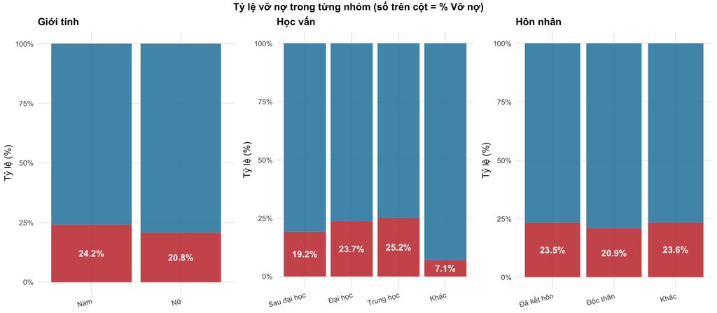

Hình 4.6. Tỷ lệ vỡ nợ trong từng nhóm nhân khẩu học

```r
plot_prop_default <- function(data, var, var_label) {
  df_pct <- data %>%
    count(.data[[var]], DEFAULT) %>%
    group_by(.data[[var]]) %>%
    mutate(pct = n / sum(n)) %>%
    filter(DEFAULT == "Vỡ nợ")

  ggplot(data, aes(x = .data[[var]], fill = DEFAULT)) +
    geom_bar(position = "fill", alpha = 0.88) +
    geom_text(data = df_pct,
              aes(x = .data[[var]], y = pct / 2,
                  label = percent(pct, accuracy = 0.1)),
              inherit.aes = FALSE,
              color = "white", fontface = "bold", size = 3.5) +
    scale_y_continuous(labels = percent_format()) +
    scale_fill_manual(values = palette_default) +
    labs(title = var_label, x = NULL, y = "Tỷ lệ (%)", fill = "Tình trạng") +
    theme_b(10) +
    theme(axis.text.x = element_text(angle = 15, hjust = 1),
          legend.position = "none")
}

grid.arrange(
  plot_prop_default(credit_eda, "SEX_label",       "Giới tính"),
  plot_prop_default(credit_eda, "EDUCATION_label", "Học vấn"),
  plot_prop_default(credit_eda, "MARRIAGE_label",  "Hôn nhân"),
  ncol = 3,
  top = grid::textGrob(
    "Tỷ lệ vỡ nợ trong từng nhóm (số trên cột = % Vỡ nợ)",
    gp = grid::gpar(fontsize = 11, fontface = "bold"))
)
```

**Nhận xét (Hình 4.6):**

- **Giới tính:** Nam có tỷ lệ vỡ nợ 24,2%, nữ là 20,8% — chênh lệch khoảng 3,4 điểm %. Đây là khác biệt nhỏ, gợi ý giới tính **không phải** yếu tố phân biệt rủi ro quan trọng.
- **Học vấn:** Tỷ lệ vỡ nợ giảm dần theo trình độ học vấn cao hơn: Trung học (25,2%) > Đại học (23,7%) > Sau đại học (19,2%). Học vấn cao hơn có thể đi kèm thu nhập ổn định hơn, dẫn đến khả năng trả nợ tốt hơn. Tuy nhiên chênh lệch vẫn khá nhỏ (~6 điểm %).
- **Hôn nhân:** Sự khác biệt giữa các nhóm không đáng kể (20–24%). Tình trạng hôn nhân có ít giá trị phân biệt rủi ro trong dữ liệu này.

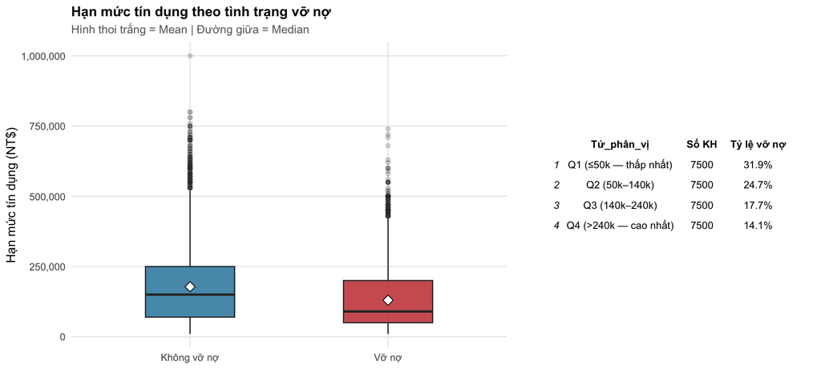

Hình 4.7. Hạn mức tín dụng (LIMIT_BAL) theo tình trạng vỡ nợ và theo tứ phân vị

```r
p_limit_box <- ggplot(credit_eda,
                      aes(x = DEFAULT, y = LIMIT_BAL, fill = DEFAULT)) +
  geom_boxplot(alpha = 0.85, outlier.alpha = 0.2, width = 0.45) +
  stat_summary(fun = mean, geom = "point",
               shape = 23, size = 3, fill = "white", color = "black") +
  scale_fill_manual(values = palette_default) +
  scale_y_continuous(labels = comma_format()) +
  labs(title    = "Hạn mức tín dụng theo tình trạng vỡ nợ",
       subtitle = "Hình thoi trắng = Mean | Đường giữa = Median",
       x = NULL, y = "Hạn mức tín dụng (NT$)") +
  theme_b(11) +
  theme(legend.position = "none")

quartile_table <- credit_eda %>%
  mutate(
    Tứ_phân_vị = ntile(LIMIT_BAL, 4),
    Tứ_phân_vị = case_when(
      Tứ_phân_vị == 1 ~ "Q1 (≤50k — thấp nhất)",
      Tứ_phân_vị == 2 ~ "Q2 (50k–140k)",
      Tứ_phân_vị == 3 ~ "Q3 (140k–240k)",
      Tứ_phân_vị == 4 ~ "Q4 (>240k — cao nhất)"
    )
  ) %>%
  group_by(Tứ_phân_vị) %>%
  summarise(`Số KH` = n(),
            `Tỷ lệ vỡ nợ` = percent(mean(DEFAULT == "Vỡ nợ"), accuracy = 0.1),
            .groups = "drop")

grid.arrange(p_limit_box,
             tableGrob(quartile_table,
                       theme = ttheme_minimal(base_size = 9)),
             ncol = 2, widths = c(2, 1.2))
```

**Nhận xét (Hình 4.7):**

Boxplot cho thấy nhóm **Không vỡ nợ** có hạn mức tín dụng cao hơn rõ rệt so với nhóm **Vỡ nợ** (median cao hơn, box rộng hơn về phía trên). Bảng tứ phân vị xác nhận xu hướng **nghịch biến** rõ ràng giữa hạn mức và rủi ro:

[figure not shown]

Hình 4.8. Tỷ lệ vỡ nợ theo trạng thái thanh toán gần nhất (PAY_0)

```r
pay0_pct <- credit_eda %>%
  count(PAY_0_nhom, DEFAULT) %>%
  group_by(PAY_0_nhom) %>%
  mutate(pct = n / sum(n)) %>%
  filter(DEFAULT == "Vỡ nợ")

ggplot(credit_eda, aes(x = PAY_0_nhom, fill = DEFAULT)) +
  geom_bar(position = "fill", alpha = 0.88) +
  geom_text(data = pay0_pct,
            aes(x = PAY_0_nhom, y = pct / 2,
                label = percent(pct, accuracy = 0.1)),
            inherit.aes = FALSE,
            color = "white", fontface = "bold", size = 4) +
  scale_y_continuous(labels = percent_format()) +
  scale_fill_manual(values = palette_default) +
  labs(title    = "Tỷ lệ vỡ nợ theo trạng thái thanh toán gần nhất (PAY_0)",
       subtitle = "Biến dự báo mạnh nhất: tăng từ 12,8% (đúng hạn) → 75,8% (trễ 3 tháng)",
       x = "Trạng thái PAY_0", y = "Tỷ lệ (%)", fill = "Tình trạng") +
  theme_b(12) +
  theme(legend.position = "bottom")
```

**Nhận xét (Hình 4.8):**

Biểu đồ cho thấy `PAY_0` là biến **quan trọng và mạnh nhất** trong toàn bộ tập dữ liệu. Tỷ lệ vỡ nợ tăng theo cấp độ trễ hạn một cách rất rõ ràng:

[output not shown]

Đáng chú ý: mức tăng **không tuyến tính** — bước nhảy từ “trễ 1 tháng” (33,9%) lên “trễ 2 tháng” (69,1%) là lớn nhất, tăng thêm hơn 35 điểm %. Điều này gợi ý **ngưỡng 2 tháng trễ hạn** là điểm cảnh báo đặc biệt quan trọng cho ngân hàng.

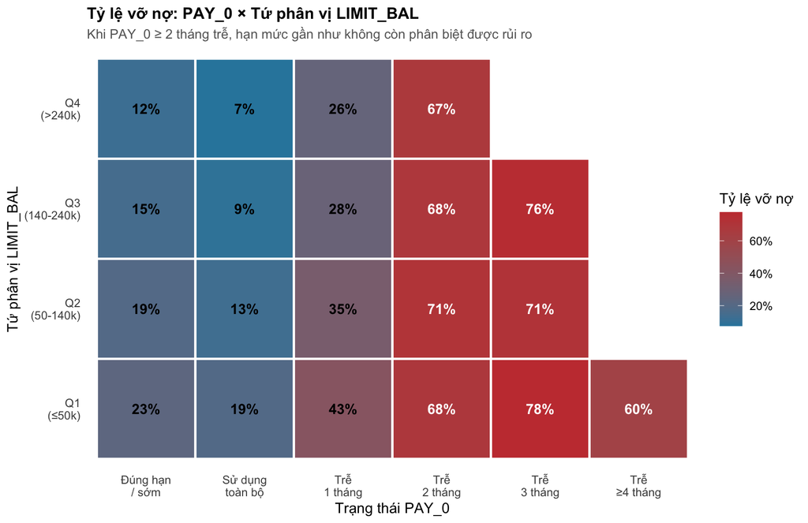

Hình 4.9. Tỷ lệ vỡ nợ theo PAY_0 × Tứ phân vị hạn mức (phân tích đa biến)

```r
heatmap_data <- credit_eda %>%
  mutate(
    limit_quartile = ntile(LIMIT_BAL, 4),
    limit_label = case_when(
      limit_quartile == 1 ~ "Q1\n(≤50k)",
      limit_quartile == 2 ~ "Q2\n(50-140k)",
      limit_quartile == 3 ~ "Q3\n(140-240k)",
      limit_quartile == 4 ~ "Q4\n(>240k)"
    ) %>%
      factor(levels = c("Q1\n(≤50k)", "Q2\n(50-140k)",
                        "Q3\n(140-240k)", "Q4\n(>240k)"))
  ) %>%
  group_by(limit_label, PAY_0_nhom) %>%
  summarise(ty_le_vo_no = mean(DEFAULT == "Vỡ nợ"),
            so_luong = n(), .groups = "drop") %>%
  filter(so_luong >= 30)

ggplot(heatmap_data,
       aes(x = PAY_0_nhom, y = limit_label, fill = ty_le_vo_no)) +
  geom_tile(color = "white", linewidth = 0.8) +
  geom_text(aes(label  = percent(ty_le_vo_no, accuracy = 1),
                color  = ty_le_vo_no > 0.45),
            fontface = "bold", size = 3.8) +
  scale_fill_gradient(low = "#2E86AB", high = "#C73E3E",
                      labels = percent_format(), name = "Tỷ lệ vỡ nợ") +
  scale_color_manual(values = c("FALSE" = "black", "TRUE" = "white"),
                     guide = "none") +
  labs(title    = "Tỷ lệ vỡ nợ: PAY_0 × Tứ phân vị LIMIT_BAL",
       subtitle = "Khi PAY_0 ≥ 2 tháng trễ, hạn mức gần như không còn phân biệt được rủi ro",
       x = "Trạng thái PAY_0", y = "Tứ phân vị LIMIT_BAL") +
  theme_b(11) +
  theme(legend.position  = "right",
        panel.grid.major = element_blank())
```

**Nhận xét (Hình 4.9):**

## 4.5 Ma trận tương quan

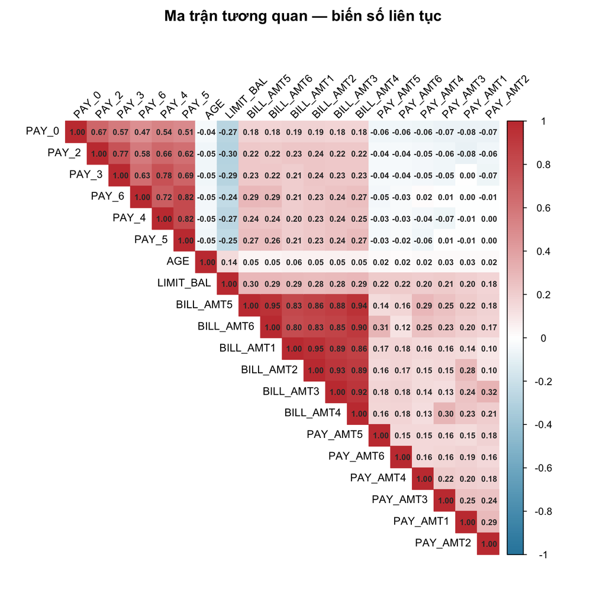

Hình 4.10. Ma trận tương quan giữa các biến số liên tục

```r
numeric_vars <- credit_eda %>%
  select(LIMIT_BAL, AGE,
         PAY_0, PAY_2, PAY_3, PAY_4, PAY_5, PAY_6,
         starts_with("BILL_AMT"), starts_with("PAY_AMT")) %>%
  select(where(is.numeric))

corr_matrix <- cor(numeric_vars, use = "complete.obs")

corrplot(corr_matrix,
         method      = "color", type = "upper", order = "hclust",
         tl.col      = "black", tl.srt = 45, tl.cex = 0.85,
         addCoef.col = "grey20", number.cex = 0.65,
         col         = colorRampPalette(c("#2E86AB","white","#C73E3E"))(200),
         title       = "Ma trận tương quan — biến số liên tục",
         mar         = c(0, 0, 2, 0))
```

**Nhận xét (Hình 4.10):**

## 4.6 Kết luận từ EDA

# 5 Mô hình hóa

## 5.1 Chiến lược mô hình hóa

Nhóm chọn ba mô hình với lý do cụ thể:

| Mô hình | Lý do lựa chọn |
| --- | --- |
| Hồi quy Logistic | Mô hình cơ sở (baseline) — đơn giản, giải thích được qua Odds Ratio, phù hợp biến mục tiêu nhị phân |
| Cây quyết định | Trực quan, dễ giải thích bằng sơ đồ cây, không cần chuẩn hóa dữ liệu |
| Random Forest | Hiệu suất cao hơn, tự nhiên tính Feature Importance, giảm overfitting so với một cây đơn lẻ |

Ba mô hình tạo thành một “thang độ phức tạp”: từ đơn giản nhất (Logistic) đến phức tạp nhất (Random Forest), giúp so sánh hiệu suất có ý nghĩa.

## 5.2 Chuẩn bị dữ liệu

```r
# Stratified split: đảm bảo tỷ lệ vỡ nợ ~22% được giữ trong cả train và test
set.seed(42)
trainIndex <- createDataPartition(credit_final$DEFAULT, p = 0.75, list = FALSE)
train_set  <- credit_final[ trainIndex, ]
test_set   <- credit_final[-trainIndex, ]

cat(sprintf("Train: %d dòng | Test: %d dòng\n",
            nrow(train_set), nrow(test_set)))
```

```
## Train: 22500 dòng | Test: 7500 dòng
```

```r
cat(sprintf("Tỷ lệ vỡ nợ — Train: %.2f%% | Test: %.2f%%\n",
            mean(train_set$DEFAULT == "Có") * 100,
            mean(test_set$DEFAULT  == "Có") * 100))
```

```
## Tỷ lệ vỡ nợ — Train: 22.12% | Test: 22.12%
```

```r
# ROSE (Random Over-Sampling Examples): tạo thêm mẫu vỡ nợ tổng hợp
# để cân bằng lớp trong train set.
# QUAN TRỌNG: Chỉ áp dụng trên TRAIN SET — test set phải giữ phân phối
# thực tế (78:22) để kết quả đánh giá phản ánh đúng thực tế triển khai.
set.seed(42)
train_balanced <- ROSE(DEFAULT ~ ., data = train_set, seed = 42)$data
cat("Phân phối sau ROSE:\n")
```

```
## Phân phối sau ROSE:
```

```r
print(table(train_balanced$DEFAULT))
```

```
##
## Không    Có
## 11241 11259
```

## 5.3 Mô hình 1: Hồi quy Logistic

**Nguyên lý:** Hồi quy Logistic không dự đoán trực tiếp nhãn 0/1 mà dự đoán **xác suất** vỡ nợ P(DEFAULT = “Có”) thông qua hàm logit. Xác suất này luôn nằm trong khoảng [0, 1], giải quyết được hạn chế của Hồi quy Tuyến tính thông thường khi áp dụng cho bài toán phân loại.

```r
logit_model <- glm(
  default_num ~ . - DEFAULT,
  data   = train_log,
  family = binomial(link = "logit")
)
summary(logit_model)
```

```
##
## Call:
## glm(formula = default_num ~ . - DEFAULT, family = binomial(link = "logit"),
##     data = train_log)
##
## Coefficients:
##                        Estimate Std. Error z value Pr(>|z|)
## (Intercept)          -6.796e-02  7.377e-02  -0.921 0.356933
## LIMIT_BAL            -7.117e-07  1.157e-07  -6.150 7.77e-10 ***
## SEXFemale            -1.216e-01  2.942e-02  -4.134 3.56e-05 ***
## EDUCATIONUniversity   7.427e-02  3.354e-02   2.214 0.026805 *
## EDUCATIONHigh School  8.682e-02  4.484e-02   1.936 0.052855 .
## EDUCATIONOthers      -1.277e+00  1.721e-01  -7.420 1.17e-13 ***
## MARRIAGESingle       -2.117e-01  3.193e-02  -6.630 3.36e-11 ***
## MARRIAGEOthers       -3.333e-01  1.346e-01  -2.477 0.013249 *
## AGE                   3.618e-03  1.414e-03   2.558 0.010517 *
## PAY_0                 2.429e-01  1.235e-02  19.662  < 2e-16 ***
## PAY_2                 7.876e-02  1.189e-02   6.623 3.52e-11 ***
## PAY_3                 5.149e-02  1.224e-02   4.207 2.58e-05 ***
## PAY_4                 2.901e-02  1.259e-02   2.304 0.021208 *
## PAY_5                 2.534e-02  1.292e-02   1.960 0.049966 *
## PAY_6                 7.903e-03  1.215e-02   0.650 0.515512
## BILL_AMT1            -3.690e-07  2.431e-07  -1.518 0.129078
## BILL_AMT2            -1.196e-07  2.599e-07  -0.460 0.645459
## BILL_AMT3             5.243e-07  2.751e-07   1.906 0.056665 .
## BILL_AMT4             2.160e-08  2.931e-07   0.074 0.941275
## BILL_AMT5            -1.278e-07  3.067e-07  -0.417 0.676941
## BILL_AMT6            -8.486e-08  3.059e-07  -0.277 0.781495
## PAY_AMT1             -6.370e-06  1.079e-06  -5.905 3.53e-09 ***
## PAY_AMT2             -2.556e-06  7.763e-07  -3.293 0.000992 ***
## PAY_AMT3             -3.003e-06  9.274e-07  -3.238 0.001202 **
## PAY_AMT4             -2.554e-06  1.009e-06  -2.531 0.011361 *
## PAY_AMT5             -1.238e-06  9.611e-07  -1.288 0.197634
## PAY_AMT6             -1.288e-06  8.452e-07  -1.524 0.127432
## total_bill           -4.452e-08  5.129e-08  -0.868 0.385410
## MAX_DELAY             1.975e-01  1.132e-02  17.439  < 2e-16 ***
## AVG_BILL              4.624e-08  3.109e-07   0.149 0.881787
## UTIL_RATE             4.718e-02  4.260e-02   1.108 0.267980
## AVG_PAY_AMT          -5.652e-06  2.164e-06  -2.612 0.008997 **
## REPAY_RATIO           3.311e-01  3.279e-02  10.097  < 2e-16 ***
## ---
## Signif. codes:  0 '***' 0.001 '**' 0.01 '*' 0.05 '.' 0.1 ' ' 1
##
## (Dispersion parameter for binomial family taken to be 1)
##
##     Null deviance: 31192  on 22499  degrees of freedom
## Residual deviance: 27877  on 22467  degrees of freedom
## AIC: 27943
##
## Number of Fisher Scoring iterations: 4
```

```r
odds_table <- data.frame(
  Variable   = names(coef(logit_model)),
  Odds_Ratio = exp(coef(logit_model))
) %>%
  arrange(desc(abs(log(Odds_Ratio)))) %>%
  head(10)

knitr::kable(odds_table, digits = 3,
             caption = "Bảng 5.1. Top 10 biến theo Odds Ratio — Hồi quy Logistic")
```

Bảng 5.1. Top 10 biến theo Odds Ratio — Hồi quy Logistic

|  | Variable | Odds_Ratio |
| --- | --- | --- |
| EDUCATIONOthers | EDUCATIONOthers | 0.279 |
| MARRIAGEOthers | MARRIAGEOthers | 0.717 |
| REPAY_RATIO | REPAY_RATIO | 1.393 |
| PAY_0 | PAY_0 | 1.275 |
| MARRIAGESingle | MARRIAGESingle | 0.809 |
| MAX_DELAY | MAX_DELAY | 1.218 |
| SEXFemale | SEXFemale | 0.885 |
| EDUCATIONHigh School | EDUCATIONHigh School | 1.091 |
| PAY_2 | PAY_2 | 1.082 |
| EDUCATIONUniversity | EDUCATIONUniversity | 1.077 |

```r
coef_table       <- summary(logit_model)$coefficients
significant_vars <- coef_table[coef_table[, 4] < 0.05, ]

knitr::kable(
  head(significant_vars[order(abs(significant_vars[, 1]), decreasing = TRUE), ], 10),
  digits  = 4,
  caption = "Bảng 5.2. Các biến có ý nghĩa thống kê (p < 0.05)"
)
```

Bảng 5.2. Các biến có ý nghĩa thống kê (p < 0.05)

|  | Estimate | Std. Error | z value | Pr(>\|z\|) |
| --- | --- | --- | --- | --- |
| EDUCATIONOthers | -1.2769 | 0.1721 | -7.4197 | 0.0000 |
| MARRIAGEOthers | -0.3333 | 0.1346 | -2.4770 | 0.0132 |
| REPAY_RATIO | 0.3311 | 0.0328 | 10.0972 | 0.0000 |
| PAY_0 | 0.2429 | 0.0124 | 19.6622 | 0.0000 |
| MARRIAGESingle | -0.2117 | 0.0319 | -6.6297 | 0.0000 |
| MAX_DELAY | 0.1975 | 0.0113 | 17.4388 | 0.0000 |
| SEXFemale | -0.1216 | 0.0294 | -4.1341 | 0.0000 |
| PAY_2 | 0.0788 | 0.0119 | 6.6230 | 0.0000 |
| EDUCATIONUniversity | 0.0743 | 0.0335 | 2.2143 | 0.0268 |
| PAY_3 | 0.0515 | 0.0122 | 4.2072 | 0.0000 |

```r
acc_logit <- calculate_accuracy(
  actual    = test_set$DEFAULT,
  predicted = pred_logistic
)
cat("Accuracy (hàm tự định nghĩa):", round(acc_logit, 4), "\n")
```

```
## Accuracy (hàm tự định nghĩa): 0.7215
```

## 5.4 Mô hình 2: Cây quyết định

**Nguyên lý:** Cây quyết định chia dữ liệu thành các nhánh dựa trên **Gini impurity** — đo lường mức độ “lẫn lộn” giữa các lớp tại mỗi nút phân chia. Thuật toán tìm biến và ngưỡng phân chia làm giảm Gini nhiều nhất. Kết quả là bộ luật “if-then” có thể visualize và giải thích cho người không chuyên kỹ thuật.

```r
tree_model <- rpart(DEFAULT ~ ., data = train_balanced, method = "class")
```

```r
# Pruning — cắt tỉa cây để tránh overfitting
# Chọn cp (complexity parameter) tại điểm có xerror (cross-validation error) nhỏ nhất
printcp(tree_model)
```

```
##
## Classification tree:
## rpart(formula = DEFAULT ~ ., data = train_balanced, method = "class")
##
## Variables actually used in tree construction:
## [1] MAX_DELAY PAY_0     PAY_2     PAY_AMT2
##
## Root node error: 11241/22500 = 0.4996
##
## n= 22500
##
##         CP nsplit rel error  xerror      xstd
## 1 0.296949      0   1.00000 1.01299 0.0066715
## 2 0.070456      1   0.70305 0.70536 0.0063747
## 3 0.013611      2   0.63259 0.64149 0.0062272
## 4 0.010000      5   0.59176 0.60075 0.0061158
```

```r
bestcp      <- tree_model$cptable[which.min(tree_model$cptable[, "xerror"]), "CP"]
pruned_tree <- prune(tree_model, cp = bestcp)
cat("CP tối ưu:", round(bestcp, 6), "\n")
```

```
## CP tối ưu: 0.01
```

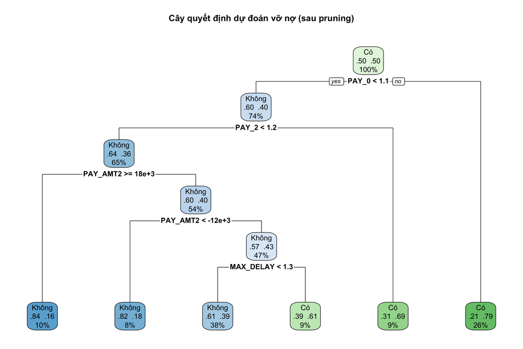

Hình 5.1. Cây quyết định sau khi cắt tỉa (pruning)

```r
rpart.plot(pruned_tree, type = 2, extra = 104, fallen.leaves = TRUE,
           main = "Cây quyết định dự đoán vỡ nợ (sau pruning)")
```

```r
dt_importance <- data.frame(
  Variable   = names(pruned_tree$variable.importance),
  Importance = pruned_tree$variable.importance
) %>% arrange(desc(Importance))

knitr::kable(head(dt_importance, 10), digits = 2,
             caption = "Bảng 5.3. Top 10 biến quan trọng — Cây quyết định")
```

Bảng 5.3. Top 10 biến quan trọng — Cây quyết định

|  | Variable | Importance |
| --- | --- | --- |
| PAY_0 | PAY_0 | 1296.81 |
| PAY_2 | PAY_2 | 594.85 |
| PAY_AMT2 | PAY_AMT2 | 403.58 |
| MAX_DELAY | MAX_DELAY | 293.72 |
| PAY_3 | PAY_3 | 121.59 |
| PAY_4 | PAY_4 | 92.87 |
| PAY_5 | PAY_5 | 92.19 |
| PAY_6 | PAY_6 | 16.67 |
| AVG_PAY_AMT | AVG_PAY_AMT | 3.64 |
| BILL_AMT4 | BILL_AMT4 | 0.82 |

```r
acc_dt <- calculate_accuracy(
  actual    = test_set$DEFAULT,
  predicted = pred_dt
)
cat("Accuracy (hàm tự định nghĩa):", round(acc_dt, 4), "\n")
```

```
## Accuracy (hàm tự định nghĩa): 0.7631
```

## 5.5 Mô hình 3: Random Forest

**Nguyên lý:** Random Forest xây dựng nhiều cây quyết định song song, mỗi cây được train trên một **bootstrap sample** (lấy mẫu ngẫu nhiên có hoàn lại từ train set) và chỉ xem xét một tập con ngẫu nhiên các biến tại mỗi nút phân chia. Dự đoán cuối cùng là **vote đa số** từ tất cả các cây. Cơ chế “ngẫu nhiên kép” này giúp các cây đa dạng hơn, giảm hiện tượng overfitting so với một cây đơn lẻ.

Ưu điểm bổ sung: Random Forest **tự động tính Feature Importance** — cho biết biến nào đóng góp nhiều nhất vào quyết định phân loại, trả lời trực tiếp câu hỏi nghiên cứu số 3.

```r
# cache=TRUE: chunk chỉ chạy lại khi code thay đổi
# ntree=500: 500 cây, đủ cho dataset 30.000 dòng
# importance=TRUE: bắt buộc để vẽ Feature Importance sau này
set.seed(42)
rf_model <- randomForest(
  DEFAULT ~ .,
  data       = train_balanced,
  ntree      = 500,
  importance = TRUE,
  nodesize   = 5
)

# OOB Error: Random Forest tự ước tính test error mà không cần tập validation
# riêng — ~37% data không được dùng để train mỗi cây, dùng để ước tính error
cat(sprintf("OOB Error Rate: %.2f%%\n",
            rf_model$err.rate[500, "OOB"] * 100))
```

```
## OOB Error Rate: 20.16%
```

# 6 Kết quả và Thảo luận

## 6.1 Kết quả Hồi quy Logistic

```r
cm_logit  <- confusionMatrix(pred_logistic, test_set$DEFAULT, positive = "Có")
roc_logit <- roc(test_set$DEFAULT, prob_logistic,
                 levels = c("Không","Có"), direction = "<", quiet = TRUE)

cat(sprintf("Accuracy   : %.4f\n", cm_logit$overall["Accuracy"]))
```

```
## Accuracy   : 0.7215
```

```r
cat(sprintf("Sensitivity: %.4f\n", cm_logit$byClass["Sensitivity"]))
```

```
## Sensitivity: 0.6781
```

```r
cat(sprintf("Specificity: %.4f\n", cm_logit$byClass["Specificity"]))
```

```
## Specificity: 0.7338
```

```r
cat(sprintf("F1-Score   : %.4f\n", cm_logit$byClass["F1"]))
```

```
## F1-Score   : 0.5186
```

```r
cat(sprintf("AUC        : %.4f\n", auc(roc_logit)))
```

```
## AUC        : 0.7541
```

**Nhận xét:** Hồi quy Logistic là mô hình baseline. Các hệ số có ý nghĩa thống kê (p < 0,05) cho phép giải thích trực tiếp qua Odds Ratio: ví dụ khi PAY_0 tăng thêm 1 đơn vị (trễ thêm 1 tháng), odds vỡ nợ tăng bao nhiêu lần. Tuy nhiên Hồi quy Logistic giả định quan hệ tuyến tính và bị ảnh hưởng bởi đa cộng tuyến — hạn chế so với hai mô hình còn lại.

## 6.2 Kết quả Cây quyết định

```r
cm_tree  <- confusionMatrix(pred_dt, test_set$DEFAULT, positive = "Có")
roc_tree <- roc(test_set$DEFAULT, prob_dt,
                levels = c("Không","Có"), direction = "<", quiet = TRUE)

cat(sprintf("Accuracy   : %.4f\n", cm_tree$overall["Accuracy"]))
```

```
## Accuracy   : 0.7631
```

```r
cat(sprintf("Sensitivity: %.4f\n", cm_tree$byClass["Sensitivity"]))
```

```
## Sensitivity: 0.6076
```

```r
cat(sprintf("Specificity: %.4f\n", cm_tree$byClass["Specificity"]))
```

```
## Specificity: 0.8072
```

```r
cat(sprintf("F1-Score   : %.4f\n", cm_tree$byClass["F1"]))
```

```
## F1-Score   : 0.5315
```

```r
cat(sprintf("AUC        : %.4f\n", auc(roc_tree)))
```

```
## AUC        : 0.7378
```

**Nhận xét:** Cây quyết định cho phép visualize bộ luật phân loại (Hình 5.1) — ưu điểm lớn khi cần giải thích cho nhân viên tín dụng không có nền tảng kỹ thuật. Tuy nhiên một cây đơn lẻ dễ **overfitting** (ghi nhớ train set quá mức) nên Pruning là bước quan trọng. Dự kiến AUC thấp hơn Random Forest nhưng cao hơn baseline random.

## 6.3 Kết quả Random Forest

```r
cm_rf  <- confusionMatrix(pred_rf, test_set$DEFAULT, positive = "Có")
roc_rf <- roc(test_set$DEFAULT, prob_rf,
              levels = c("Không","Có"), direction = "<", quiet = TRUE)

cat(sprintf("Accuracy   : %.4f\n", cm_rf$overall["Accuracy"]))
```

```
## Accuracy   : 0.7273
```

```r
cat(sprintf("Sensitivity: %.4f\n", cm_rf$byClass["Sensitivity"]))
```

```
## Sensitivity: 0.6691
```

```r
cat(sprintf("Specificity: %.4f\n", cm_rf$byClass["Specificity"]))
```

```
## Specificity: 0.7439
```

```r
cat(sprintf("F1-Score   : %.4f\n", cm_rf$byClass["F1"]))
```

```
## F1-Score   : 0.5205
```

```r
cat(sprintf("AUC        : %.4f\n", auc(roc_rf)))
```

```
## AUC        : 0.7667
```

```r
cat(sprintf("OOB Error  : %.2f%%\n",
            rf_model$err.rate[500, "OOB"] * 100))
```

```
## OOB Error  : 20.16%
```

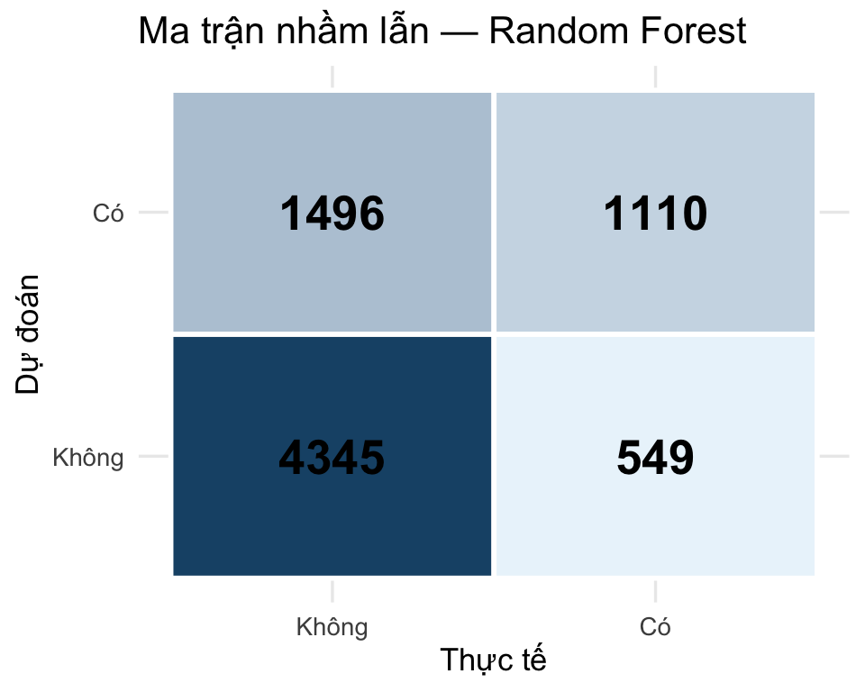

Hình 6.1. Ma trận nhầm lẫn — Random Forest

```r
cm_rf_df <- as.data.frame(cm_rf$table)
colnames(cm_rf_df) <- c("Du_doan", "Thuc_te", "So_luong")

ggplot(cm_rf_df, aes(x = Thuc_te, y = Du_doan, fill = So_luong)) +
  geom_tile(color = "white", linewidth = 1) +
  geom_text(aes(label = So_luong), size = 7, fontface = "bold") +
  scale_fill_gradient(low = "#EBF5FB", high = "#1A5276") +
  labs(title = "Ma trận nhầm lẫn — Random Forest",
       x = "Thực tế", y = "Dự đoán") +
  theme_minimal(base_size = 13) +
  theme(legend.position = "none")
```

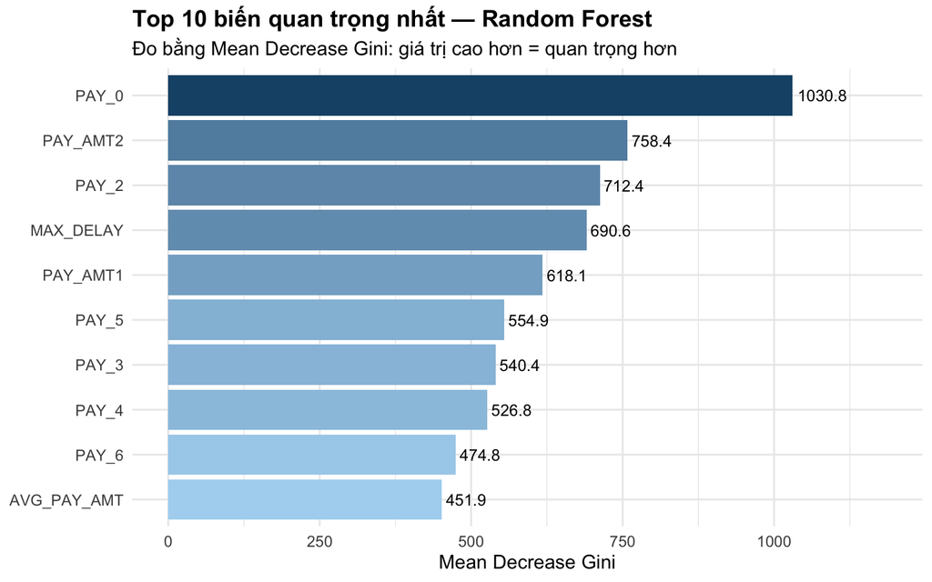

Hình 6.2. Top 10 biến quan trọng nhất — Random Forest (Feature Importance)

```r
importance_df <- as.data.frame(importance(rf_model)) %>%
  mutate(Feature = rownames(.)) %>%
  arrange(desc(MeanDecreaseGini)) %>%
  head(10) %>%
  mutate(Feature = factor(Feature, levels = rev(Feature)))

ggplot(importance_df, aes(x = Feature, y = MeanDecreaseGini,
                           fill = MeanDecreaseGini)) +
  geom_col(show.legend = FALSE) +
  geom_text(aes(label = round(MeanDecreaseGini, 1)),
            hjust = -0.1, size = 3.5) +
  scale_fill_gradient(low = "#AED6F1", high = "#1A5276") +
  coord_flip() +
  labs(title    = "Top 10 biến quan trọng nhất — Random Forest",
       subtitle = "Đo bằng Mean Decrease Gini: giá trị cao hơn = quan trọng hơn",
       x = NULL, y = "Mean Decrease Gini") +
  theme_minimal(base_size = 12) +
  theme(plot.title = element_text(face = "bold")) +
  expand_limits(y = max(importance_df$MeanDecreaseGini) * 1.15)
```

**Nhận xét (Hình 6.2 — Feature Importance):**

**Mean Decrease Gini** đo lường: nếu xóa biến này đi, tổng độ “lẫn lộn” (Gini impurity) trong tất cả các cây tăng thêm bao nhiêu. Giá trị càng cao → biến càng quan trọng.

## 6.4 So sánh ba mô hình

```r
results <- bind_rows(
  get_metrics(test_set$DEFAULT, pred_logistic, prob_logistic, "Hồi quy Logistic"),
  get_metrics(test_set$DEFAULT, pred_dt,       prob_dt,       "Cây quyết định"),
  get_metrics(test_set$DEFAULT, pred_rf,       prob_rf,       "Random Forest")
)

best_row <- which.max(results$AUC)

knitr::kable(results,
             caption = "Bảng 6.1. So sánh hiệu suất ba mô hình trên tập kiểm tra (n = 7.500)",
             align   = c("l","c","c","c","c","c","c"),
             digits  = 4) %>%
  kableExtra::kable_styling(
    bootstrap_options = c("striped","hover","condensed","bordered"),
    full_width = FALSE) %>%
  kableExtra::row_spec(best_row, bold = TRUE, background = "#D5F5E3") %>%
  kableExtra::column_spec(3, bold = TRUE) %>%
  kableExtra::footnote(general = paste(
    "Hàng highlight xanh = AUC cao nhất.",
    "Cột Sensitivity in đậm vì quan trọng nhất trong bài toán rủi ro tín dụng:",
    "bỏ sót người vỡ nợ (False Negative) tốn kém hơn cảnh báo nhầm (False Positive)."))
```

Bảng 6.1. So sánh hiệu suất ba mô hình trên tập kiểm tra (n = 7.500)

|  | Mô hình | Accuracy | Sensitivity | Specificity | Precision | F1_Score | AUC |
| --- | --- | --- | --- | --- | --- | --- | --- |
| Accuracy…1 | Hồi quy Logistic | 0.7215 | 0.6781 | 0.7338 | 0.4198 | 0.5186 | 0.7541 |
| Accuracy…2 | Cây quyết định | 0.7631 | 0.6076 | 0.8072 | 0.4724 | 0.5315 | 0.7378 |
| Accuracy…3 | Random Forest | 0.7273 | 0.6691 | 0.7439 | 0.4259 | 0.5205 | 0.7667 |

Note:  
Hàng highlight xanh = AUC cao nhất. Cột Sensitivity in đậm vì quan trọng nhất trong bài toán rủi ro tín dụng: bỏ sót người vỡ nợ (False Negative) tốn kém hơn cảnh báo nhầm (False Positive).

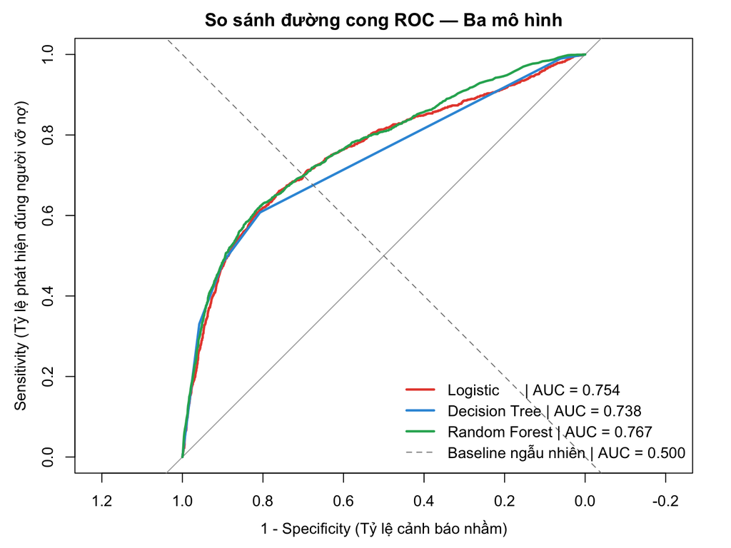

Hình 6.3. So sánh đường cong ROC — Ba mô hình phân loại

```r
plot(roc_logit, col = "#E74C3C", lwd = 2.5,
     main = "So sánh đường cong ROC — Ba mô hình",
     xlab = "1 - Specificity (Tỷ lệ cảnh báo nhầm)",
     ylab = "Sensitivity (Tỷ lệ phát hiện đúng người vỡ nợ)")
lines(roc_tree, col = "#3498DB", lwd = 2.5)
lines(roc_rf,   col = "#27AE60", lwd = 2.5)
abline(a = 0, b = 1, lty = 2, col = "gray50")
legend("bottomright",
       legend = c(
         sprintf("Logistic      | AUC = %.3f", auc(roc_logit)),
         sprintf("Decision Tree | AUC = %.3f", auc(roc_tree)),
         sprintf("Random Forest | AUC = %.3f", auc(roc_rf)),
         "Baseline ngẫu nhiên | AUC = 0.500"
       ),
       col = c("#E74C3C","#3498DB","#27AE60","gray50"),
       lwd = c(2.5,2.5,2.5,1), lty = c(1,1,1,2), bty = "n")
```

**Nhận xét (Bảng 6.1 và Hình 6.3):**

**Đường cong ROC** (Hình 6.3) cho thấy đường của mô hình nào nằm càng xa đường chéo (baseline ngẫu nhiên) và càng gần góc trên bên trái thì mô hình đó phân loại tốt hơn. **AUC (Area Under Curve)** là diện tích dưới đường cong — giá trị từ 0,5 (ngẫu nhiên) đến 1,0 (hoàn hảo).

**Random Forest đạt AUC = 0.7667**, cao hơn Hồi quy Logistic (0.7541) và Cây quyết định (0.7378). Lý do:

- *So với Logistic:* Random Forest xử lý tốt hơn quan hệ phi tuyến (như bước nhảy đột ngột của PAY_0 từ 33% → 69%) và không bị ảnh hưởng bởi đa cộng tuyến của BILL_AMT.
- *So với Decision Tree đơn lẻ:* Ensemble 500 cây giảm variance và ít overfitting hơn.

**Về Sensitivity** (quan trọng nhất trong bài toán tín dụng): Trong thực tế ngân hàng, **bỏ sót một người vỡ nợ** (False Negative = dự đoán “không vỡ nợ” nhưng thực tế họ vỡ nợ) gây tổn thất tài chính trực tiếp, trong khi **cảnh báo nhầm** (False Positive = dự đoán “vỡ nợ” nhưng thực ra không) chỉ tốn thêm chi phí xem xét hồ sơ. Do đó Sensitivity cao hơn được ưu tiên hơn Accuracy cao.

## 6.5 Thảo luận chung

**Tính nhất quán giữa EDA và mô hình:** Feature Importance của Random Forest xác nhận PAY_0 và PAY_AMT2 là hai biến quan trọng nhất — nhất quán hoàn toàn với phát hiện EDA ở Mục 4.4 rằng `PAY_0 ≥ 2` dẫn đến tỷ lệ vỡ nợ 69,1%. Khi EDA và mô hình cho kết quả cùng chiều, độ tin cậy của phân tích tăng lên đáng kể.

**Hàm ý thực tiễn:** Dựa trên kết quả, nhóm đề xuất hệ thống cảnh báo ba mức:

[output not shown]

# 7 Kết luận

## 7.2 Đề xuất cho ngân hàng

- Triển khai hệ thống cảnh báo sớm dựa trên Random Forest, kích hoạt tự động khi `PAY_0 ≥ 1`.
- Ưu tiên theo dõi khách hàng có hạn mức thấp (Q1 ≤ 50.000 NT$) kết hợp với `UTIL_RATE > 0.8` — nhóm rủi ro kép.
- Giải quyết khiếu nại của khách hàng nhanh chóng để duy trì hành vi thanh toán tích cực.
- Xem xét điều chỉnh ngưỡng quyết định của mô hình (thay vì mặc định 0.5) tùy theo mức chấp nhận rủi ro của ngân hàng.

## 7.3 Hạn chế và hướng phát triển

**Hạn chế của nghiên cứu:**

- Dữ liệu từ Đài Loan năm 2005 — hành vi tín dụng và môi trường kinh tế có thể khác biệt đáng kể so với hiện tại.
- Chưa thử các thuật toán nâng cao hơn như XGBoost hay Neural Network, có thể cho AUC cao hơn.
- Chưa tối ưu ngưỡng quyết định (threshold) theo chi phí thực tế của từng loại lỗi (False Negative vs False Positive).

**Hướng phát triển tiếp theo:**

- Thử nghiệm XGBoost và so sánh với Random Forest.
- Xây dựng mô hình dự đoán nhiều bước trước (dự đoán vỡ nợ 2–3 tháng tới thay vì chỉ tháng tới).
- Tối ưu ngưỡng quyết định dựa trên phân tích chi phí-lợi ích thực tế.

# 8 Phụ lục

GitHub: https://github.com/thaongan1202/CreditCard-Default-Prediction-R.git

# 9 Đóng góp

| Thành viên | MSSV | Nhiệm vụ |
| --- | --- | --- |
| Lâm Ngọc Yến Vy | 24133076 | Tiền xử lý dữ liệu, Feature Engineering (Mục 3) |
| Trần Thị Quế Trân | 24133067 | Trực quan hóa dữ liệu, EDA (Mục 4) |
| Tô Thuỷ Tiên | 24133062 | Hồi quy Logistic, Cây quyết định (Mục 5.3–5.4) |
| Phạm Thị Thảo Ngân | 24133041 | Random Forest, So sánh mô hình, Tích hợp (Mục 5.5, 6) |

# 10 Tham khảo

- Yeh, I. C., & Lien, C. H. (2009). The comparisons of data mining techniques for the predictive accuracy of probability of default of credit card clients. *Expert Systems with Applications*, 36(2), 2473–2480.
- Wickham, H., & Grolemund, G. (2017). *R for Data Science*. O’Reilly Media.
- Tài liệu môn học Lập trình R cho Phân tích Dữ liệu — HCMUTE.

# 11 Peer Assessment

**Đánh giá chung:** Nhóm đã phân công rõ ràng, họp nhóm định kỳ để kiểm tra tiến độ và hỗ trợ nhau giải quyết vấn đề kỹ thuật. File Rmd được tích hợp và kiểm tra chạy từ đầu đến cuối trước khi nộp.